# 2026-05-06_hw05

Chris

2026-05-06

The project is on GitHub: https://github.com/ChrisW12372/2026-05-06_p8106-hw05.git

```r
library(tidyverse)
library(tidymodels)
library(caret)
library(kernlab)
library(e1071)
library(gbm)
library(ISLR)
library(factoextra)

set.seed(202605)
```

# 1 Problem One

```r
set.seed(202605)
df_auto <- read_csv("data/auto.csv") |>
  mutate(
    mpg_cat = factor(mpg_cat),
    origin = factor(origin)
  )
data_split <- initial_split(df_auto, prop = 0.7)
df_auto_train <- training(data_split)
df_auto_test <- testing(data_split)
```

## 1.1 Part I

```r
set.seed(202605)

cost_grid <- exp(seq(-5, 5, len = 100))

linear_tune_svc <- tune.svm(
  mpg_cat ~ cylinders + displacement + horsepower + weight +
    acceleration + year + origin,
  data = df_auto_train,
  kernel = "linear",
  cost = cost_grid,
  scale = TRUE,
  tunecontrol = tune.control(cross = 10)
)
```

```r
summary(linear_tune_svc)
```

```
##
## Parameter tuning of 'svm':
##
## - sampling method: 10-fold cross validation
##
## - best parameters:
##      cost
##  3.534692
##
## - best performance: 0.07645503
##
## - Detailed performance results:
##             cost      error dispersion
## 1   6.737947e-03 0.11283069 0.05797700
## 2   7.454109e-03 0.10939153 0.05757321
```

[output cut: 98 more lines]

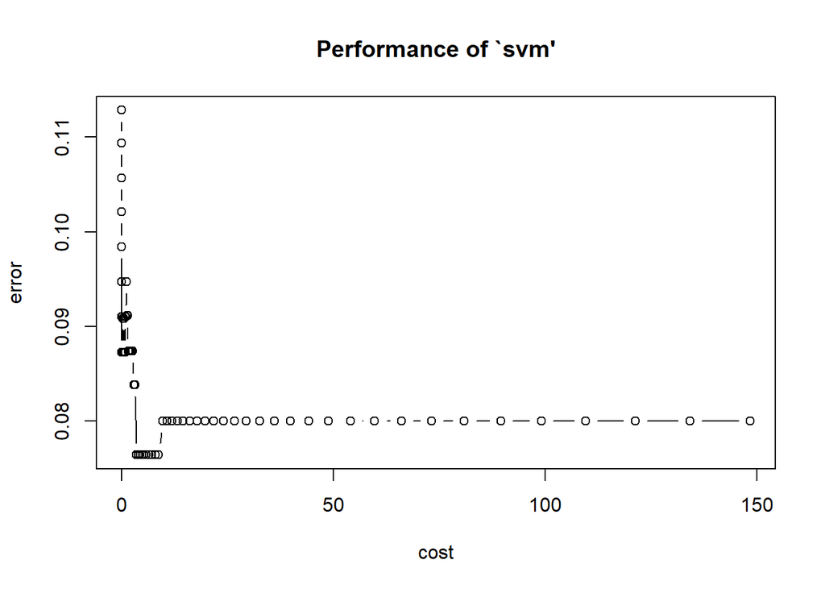

```r
plot(linear_tune_svc)
```

```r
linear_tune_svc$best.parameters
```

```
##        cost
## 63 3.534692
```

```r
# get the optimal classifier
best_svc <- linear_tune_svc$best.model
```

```r
svc_train_pred <- predict(best_svc, newdata = df_auto_train)
svc_train_error <- mean(svc_train_pred != df_auto_train$mpg_cat)

svc_train_error
```

```
## [1] 0.08029197
```

```r
svc_test_pred <- predict(best_svc, newdata = df_auto_test)
svc_test_error <- mean(svc_test_pred != df_auto_test$mpg_cat)

svc_test_error
```

```
## [1] 0.06779661
```

```r
df_svc_result <- tibble(
  Model = "SVC",
  Best_Cost = linear_tune_svc$best.parameters$cost,
  Training_Error = svc_train_error,
  Test_Error = svc_test_error
)

df_svc_result
```

```
## # A tibble: 1 × 4
##   Model Best_Cost Training_Error Test_Error
##   <chr>     <dbl>          <dbl>      <dbl>
## 1 SVC        3.53         0.0803     0.0678
```

I fit a support vector classifier with a linear kernel using the `e1071` package. The cost parameter was selected by 10-fold cross-validation. The best selected cost was `3.535`. Using this model, the training error rate was `0.0803`, and the test error rate was `0.0678`.

## 1.2 Part II

```r
set.seed(202605)

cost_grid <- exp(seq(-5, 5, len = 30))
gamma_grid <- exp(seq(-10, -2, len = 30))

radial_tune_svm <- tune.svm(
  mpg_cat ~ cylinders + displacement + horsepower + weight +
    acceleration + year + origin,
  data = df_auto_train,
  kernel = "radial",
  cost = cost_grid,
  gamma = gamma_grid,
  scale = TRUE,
  tunecontrol = tune.control(cross = 10)
)

summary(radial_tune_svm)
```

```
##
## Parameter tuning of 'svm':
##
## - sampling method: 10-fold cross validation
##
## - best parameters:
##       gamma     cost
##  0.01130219 26.46603
##
## - best performance: 0.08002646
##
## - Detailed performance results:
##            gamma         cost      error dispersion
## 1   4.539993e-05 6.737947e-03 0.56230159 0.05402791
## 2   5.982195e-05 6.737947e-03 0.56230159 0.05402791
```

[output cut: 898 more lines]

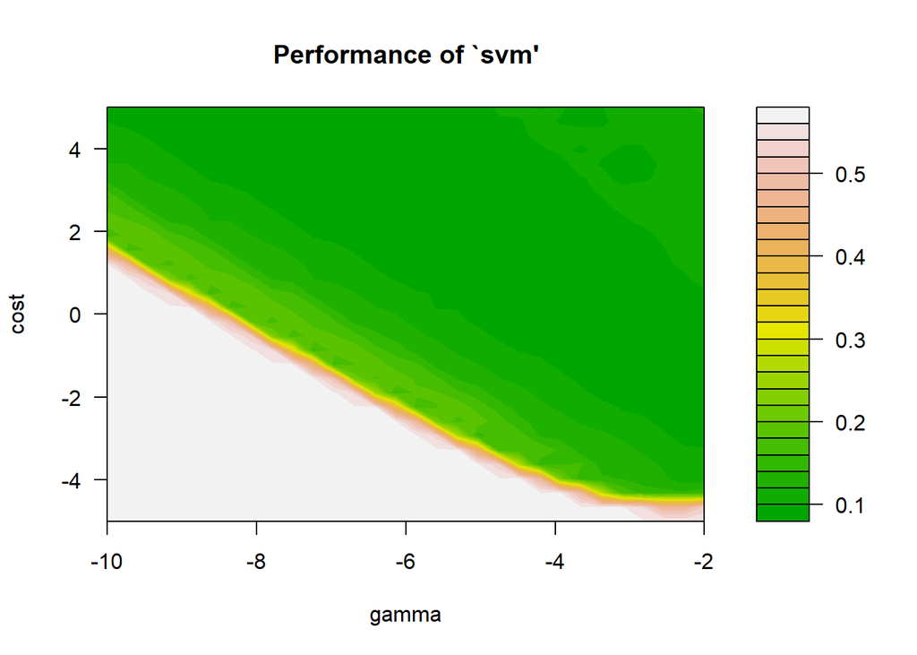

```r
plot(
  radial_tune_svm,
  transform.y = log,
  transform.x = log,
  color.palette = terrain.colors
)
```

```r
best_radial_svm <- radial_tune_svm$best.model
```

```r
radial_train_pred <- predict(best_radial_svm, newdata = df_auto_train)

radial_train_error <- mean(radial_train_pred != df_auto_train$mpg_cat)

radial_train_error
```

```
## [1] 0.07664234
```

```r
radial_test_pred <- predict(best_radial_svm, newdata = df_auto_test)

radial_test_error <- mean(radial_test_pred != df_auto_test$mpg_cat)

radial_test_error
```

```
## [1] 0.06779661
```

```r
df_radial_result <- tibble(
  Model = "Radial SVM",
  Best_Cost = radial_tune_svm$best.parameters$cost,
  Best_Gamma = radial_tune_svm$best.parameters$gamma,
  Training_Error = radial_train_error,
  Test_Error = radial_test_error
)

df_radial_result
```

```
## # A tibble: 1 × 5
##   Model      Best_Cost Best_Gamma Training_Error Test_Error
##   <chr>          <dbl>      <dbl>          <dbl>      <dbl>
## 1 Radial SVM      26.5     0.0113         0.0766     0.0678
```

Using 10-fold cross-validation, the best radial SVM selected `cost = 26.466` and `gamma = 0.0113`. The resulting training error rate was `7.66%`, and the test error rate was `6.78%`. Compared with the linear SVC, the radial SVM slightly reduced the training error, but it did not improve the test error rate.

## 1.3 Part III

```r
set.seed(202605)

ctrl <- trainControl(
  method = "cv",
  number = 10
)

gbm_grid <- expand.grid(
  n.trees = c(100, 200, 500, 1000, 2000, 5000),
  interaction.depth = 1:4,
  shrinkage = c(0.005, 0.01, 0.05),
  n.minobsinnode = c(10)
)
```

```r
set.seed(202605)

gbm_fit <- train(
  mpg_cat ~ cylinders + displacement + horsepower + weight +
    acceleration + year + origin,
  data = df_auto_train,
  method = "gbm",
  tuneGrid = gbm_grid,
  trControl = ctrl,
  metric = "Accuracy",
  verbose = FALSE
)

gbm_fit
```

```
## Stochastic Gradient Boosting
##
## 274 samples
##   7 predictor
##   2 classes: 'high', 'low'
##
## No pre-processing
## Resampling: Cross-Validated (10 fold)
## Summary of sample sizes: 247, 246, 247, 247, 247, 247, ...
## Resampling results across tuning parameters:
##
##   shrinkage  interaction.depth  n.trees  Accuracy   Kappa
##   0.005      1                   100     0.8865079  0.7725332
##   0.005      1                   200     0.8865079  0.7725332
##   0.005      1                   500     0.9047619  0.8092562
##   0.005      1                  1000     0.9085979  0.8171127
##   0.005      1                  2000     0.9084656  0.8171004
##   0.005      1                  5000     0.9048942  0.8097946
##   0.005      2                   100     0.8900794  0.7796760
##   0.005      2                   200     0.8937831  0.7871966
##   0.005      2                   500     0.9085979  0.8171127
##   0.005      2                  1000     0.9121693  0.8243774
##   0.005      2                  2000     0.9084656  0.8169375
##   0.005      2                  5000     0.9195767  0.8388875
##   0.005      3                   100     0.9084656  0.8166539
##   0.005      3                   200     0.9084656  0.8166539
##   0.005      3                   500     0.9158730  0.8316941
##   0.005      3                  1000     0.9085979  0.8172345
##   0.005      3                  2000     0.9158730  0.8315312
##   0.005      3                  5000     0.9194444  0.8385101
##   0.005      4                   100     0.9157407  0.8312759
##   0.005      4                   200     0.9085979  0.8169902
##   0.005      4                   500     0.9160053  0.8319484
##   0.005      4                  1000     0.9120370  0.8240413
##   0.005      4                  2000     0.9194444  0.8386741
##   0.005      4                  5000     0.9157407  0.8311535
##   0.010      1                   100     0.8829365  0.7653903
##   0.010      1                   200     0.8974868  0.7946755
##   0.010      1                   500     0.9158730  0.8317347
##   0.010      1                  1000     0.9048942  0.8099575
```

[output cut: 34 more lines]

```
##   0.050      3                   500     0.9194444  0.8385101
##   0.050      3                  1000     0.9158730  0.8313673
##   0.050      3                  2000     0.9121693  0.8240107
##   0.050      3                  5000     0.9160053  0.8317038
##   0.050      4                   100     0.9158730  0.8316941
##   0.050      4                   200     0.9231481  0.8461530
##   0.050      4                   500     0.9193122  0.8382964
##   0.050      4                  1000     0.9231481  0.8459895
##   0.050      4                  2000     0.9231481  0.8459895
##   0.050      4                  5000     0.9160053  0.8317038
##
## Tuning parameter 'n.minobsinnode' was held constant at a value of 10
## Accuracy was used to select the optimal model using the largest value.
## The final values used for the model were n.trees = 200, interaction.depth =
##  4, shrinkage = 0.05 and n.minobsinnode = 10.
```

```r
gbm_fit$bestTune
```

```
##    n.trees interaction.depth shrinkage n.minobsinnode
## 68     200                 4      0.05             10
```

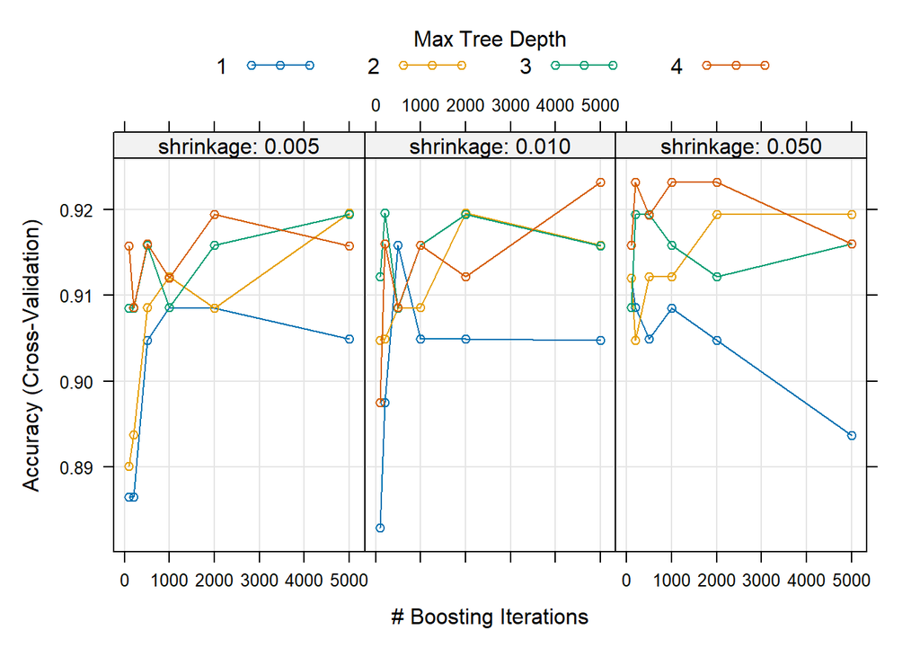

```r
plot(gbm_fit)
```

```r
gbm_train_pred <- predict(gbm_fit, newdata = df_auto_train)
gbm_test_pred <- predict(gbm_fit, newdata = df_auto_test)

gbm_train_error <- mean(gbm_train_pred != df_auto_train$mpg_cat)
gbm_test_error <- mean(gbm_test_pred != df_auto_test$mpg_cat)

df_gbm_result <- tibble(
  Model = "Boosting",
  Best_n_trees = gbm_fit$bestTune$n.trees,
  Best_Depth = gbm_fit$bestTune$interaction.depth,
  Best_Shrinkage = gbm_fit$bestTune$shrinkage,
  Best_Minobsinnode = gbm_fit$bestTune$n.minobsinnode,
  Training_Error = gbm_train_error,
  Test_Error = gbm_test_error
)

df_gbm_result
```

```
## # A tibble: 1 × 7
##   Model  Best_n_trees Best_Depth Best_Shrinkage Best_Minobsinnode Training_Error
##   <chr>         <dbl>      <int>          <dbl>             <dbl>          <dbl>
## 1 Boost…          200          4           0.05                10         0.0109
## # ℹ 1 more variable: Test_Error <dbl>
```

```r
df_model_compare <- tibble(
  Model = c("SVC", "Radial SVM", "Boosting"),
  Training_Error = c(
    svc_train_error,
    radial_train_error,
    gbm_train_error
  ),
  Test_Error = c(
    svc_test_error,
    radial_test_error,
    gbm_test_error
  )
)

df_model_compare
```

```
## # A tibble: 3 × 3
##   Model      Training_Error Test_Error
##   <chr>               <dbl>      <dbl>
## 1 SVC                0.0803     0.0678
## 2 Radial SVM         0.0766     0.0678
## 3 Boosting           0.0109     0.0424
```

The performance of the three models was compared using the test error rate. The SVC and radial SVM both had a test error rate of `0.0678`, while the boosting model had a lower test error rate of `0.0424`. Therefore, boosting provided the best predictive performance on this dataset. Neither the linear SVC nor the radial kernel SVM outperformed boosting.

# 2 Problem Two

```r
data("USArrests")
```

## 2.1 Part I

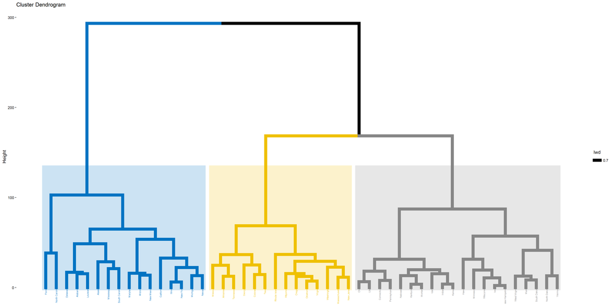

```r
hc_complete <- hclust(
  dist(USArrests),
  method = "complete"
)

fviz_dend(
  hc_complete,
  k = 3,
  cex = 0.4,
  palette = "jco",
  color_labels_by_k = TRUE,
  rect = TRUE,
  rect_fill = TRUE,
  rect_border = "jco",
  labels_track_height = 2.5
)
```

```r
cluster_unscaled <- cutree(hc_complete, k = 3)
split(names(cluster_unscaled), cluster_unscaled)
```

```
## $`1`
##  [1] "Alabama"        "Alaska"         "Arizona"        "California"
##  [5] "Delaware"       "Florida"        "Illinois"       "Louisiana"
##  [9] "Maryland"       "Michigan"       "Mississippi"    "Nevada"
## [13] "New Mexico"     "New York"       "North Carolina" "South Carolina"
##
## $`2`
##  [1] "Arkansas"      "Colorado"      "Georgia"       "Massachusetts"
##  [5] "Missouri"      "New Jersey"    "Oklahoma"      "Oregon"
##  [9] "Rhode Island"  "Tennessee"     "Texas"         "Virginia"
## [13] "Washington"    "Wyoming"
##
## $`3`
##  [1] "Connecticut"   "Hawaii"        "Idaho"         "Indiana"
##  [5] "Iowa"          "Kansas"        "Kentucky"      "Maine"
##  [9] "Minnesota"     "Montana"       "Nebraska"      "New Hampshire"
## [13] "North Dakota"  "Ohio"          "Pennsylvania"  "South Dakota"
## [17] "Utah"          "Vermont"       "West Virginia" "Wisconsin"
```

## 2.2 Part II

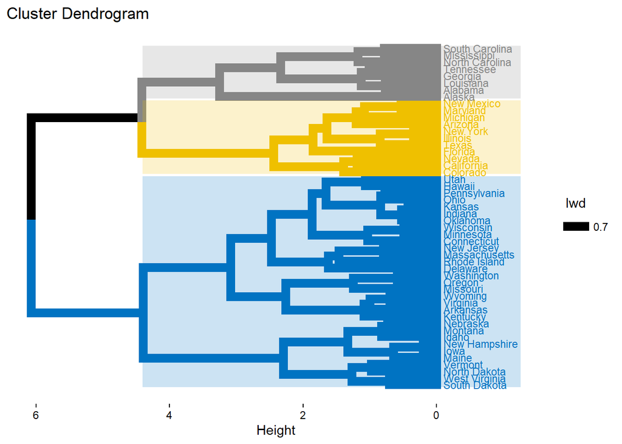

```r
# Scale the variables
dat_scaled <- scale(USArrests)

# Hierarchical clustering with complete linkage and Euclidean distance
hc_complete_scaled <- hclust(
  dist(dat_scaled),
  method = "complete"
)

# Plot dendrogram
fviz_dend(
  hc_complete_scaled,
  k = 3,
  horiz = TRUE,
  cex = 0.6,
  palette = "jco",
  color_labels_by_k = TRUE,
  rect = TRUE,
  rect_fill = TRUE,
  rect_border = "jco"
)
```

```r
# Cut into 3 clusters
cluster_scaled <- cutree(hc_complete_scaled, k = 3)

# List states in each cluster
cluster_list_scaled <- split(names(cluster_scaled), cluster_scaled)

cluster_list_scaled
```

```
## $`1`
## [1] "Alabama"        "Alaska"         "Georgia"        "Louisiana"
## [5] "Mississippi"    "North Carolina" "South Carolina" "Tennessee"
##
## $`2`
##  [1] "Arizona"    "California" "Colorado"   "Florida"    "Illinois"
##  [6] "Maryland"   "Michigan"   "Nevada"     "New Mexico" "New York"
## [11] "Texas"
##
## $`3`
##  [1] "Arkansas"      "Connecticut"   "Delaware"      "Hawaii"
##  [5] "Idaho"         "Indiana"       "Iowa"          "Kansas"
##  [9] "Kentucky"      "Maine"         "Massachusetts" "Minnesota"
## [13] "Missouri"      "Montana"       "Nebraska"      "New Hampshire"
## [17] "New Jersey"    "North Dakota"  "Ohio"          "Oklahoma"
## [21] "Oregon"        "Pennsylvania"  "Rhode Island"  "South Dakota"
## [25] "Utah"          "Vermont"       "Virginia"      "Washington"
## [29] "West Virginia" "Wisconsin"     "Wyoming"
```

```r
# Compare with unscaled clustering
table(
  Unscaled = cluster_unscaled,
  Scaled = cluster_scaled
)
```

```
##         Scaled
## Unscaled  1  2  3
##        1  6  9  1
##        2  2  2 10
##        3  0  0 20
```

- After scaling the variables to have standard deviation one, I repeated hierarchical clustering using complete linkage and Euclidean distance and cut the dendrogram into three clusters.
- The resulting clusters were:
  - Cluster 1: Alabama, Alaska, Georgia, Louisiana, Mississippi, North Carolina, South Carolina, Tennessee.
  - Cluster 2: Arizona, California, Colorado, Florida, Illinois, Maryland, Michigan, Nevada, New Mexico, New York, Texas.
  - Cluster 3: Arkansas, Connecticut, Delaware, Hawaii, Idaho, Indiana, Iowa, Kansas, Kentucky, Maine, Massachusetts, Minnesota, Missouri, Montana, Nebraska, New Hampshire, New Jersey, North Dakota, Ohio, Oklahoma, Oregon, Pennsylvania, Rhode Island, South Dakota, Utah, Vermont, Virginia, Washington, West Virginia, Wisconsin, Wyoming.

Scaling changed the clustering results. The cross-tabulation between the unscaled and scaled cluster assignments shows that several states moved to different clusters after scaling.In my opinion, the variables should be scaled before computing the inter-observation dissimilarities. The variables are measured on different scales, and Euclidean distance can be dominated by variables with larger numerical ranges, such as Assault. Scaling puts the variables on a comparable scale, so each variable contributes more equally to the distance calculation.